# Describe: alcohol

This report lists the candidate variable for DataScheme variables of the construct **alcohol**.

# Exposition

> This report is meant to be compiled after having executed the script `./manipulation/0-ellis-island.R`, which prepares the necessary data transfer object (DTO). We begin with a brief recap of this script and the DTO it produces.

## Ellis Island

> All data land on Ellis Island.

The script `0-ellis-island.R` is the first script in the analytic workflow. It accomplished the following:

- 1. Reads in raw data files from the candidate studies
- 2. Extract, combines, and exports their metadata (specifically, variable names and labels, if provided) into `./data/shared/derived/meta-data-live.csv`, which is updated every time Ellis Island script is executed.
- 3. Augments raw metadata with instructions for renaming and classifying variables. The instructions are provided as manually entered values in `./data/shared/meta-data-map.csv`. They are used by automatic scripts in later harmonization and analysis.
- 4. Combines unit and metadata into a single DTO to serve as a starting point to all subsequent analyses.

```r
# load the product of 0-ellis-island.R,  a list object containing data and metadata
dto <- readRDS("./data/unshared/derived/dto.rds")
```

```r
# the list is composed of the following elements
names(dto)
```

```
[1] "studyName" "filePath"  "unitData"  "metaData"
```

```r
# 1st element - names of the studies as character vector
dto[["studyName"]]
```

```
[1] "alsa"  "lbsl"  "satsa" "share" "tilda"
```

```r
# 2nd element - file paths of the data files for each study as character vector
dto[["filePath"]]
```

```
[1] "./data/unshared/raw/ALSA-Wave1.Final.sav"         "./data/unshared/raw/LBSL-Panel2-Wave1.Final.sav"
[3] "./data/unshared/raw/SATSA-Q3.Final.sav"           "./data/unshared/raw/SHARE-Israel-Wave1.Final.sav"
[5] "./data/unshared/raw/TILDA-Wave1.Final.sav"
```

```r
# 3rd element - list objects with the following elements
names(dto[["unitData"]])
```

```
[1] "alsa"  "lbsl"  "satsa" "share" "tilda"
```

```r
# each of these elements is a raw data set of a corresponding study, for example
dplyr::tbl_df(dto[["unitData"]][["lbsl"]])
```

```
Source: local data frame [656 x 26]

        id AGE94 SEX94  MSTAT94 EDUC94     NOWRK94  SMK94                                         SMOKE
     (int) (int) (int)   (fctr)  (int)      (fctr) (fctr)                                        (fctr)
1  4001026    68     1 divorced     16 no, retired     no                                  never smoked
2  4012015    94     2  widowed     12 no, retired     no                                  never smoked
3  4012032    94     2  widowed     20 no, retired     no don't smoke at present but smoked in the past
4  4022004    93     2       NA     NA          NA     NA                                  never smoked
5  4022026    93     2  widowed     12 no, retired     no                                  never smoked
6  4031031    92     1  married      8 no, retired     no don't smoke at present but smoked in the past
7  4031035    92     1  widowed     13 no, retired     no don't smoke at present but smoked in the past
8  4032201    92     2       NA     NA          NA     NA don't smoke at present but smoked in the past
9  4041062    91     1  widowed      7          NA     no don't smoke at present but smoked in the past
10 4042057    91     2       NA     NA          NA     NA                                            NA
..     ...   ...   ...      ...    ...         ...    ...                                           ...
Variables not shown: ALCOHOL (fctr), WINE (int), BEER (int), HARDLIQ (int), SPORT94 (int), FIT94 (int), WALK94 (int),
  SPEC94 (int), DANCE94 (int), CHORE94 (int), EXCERTOT (int), EXCERWK (int), HEIGHT94 (int), WEIGHT94 (int), HWEIGHT
  (int), HHEIGHT (int), SRHEALTH (fctr), year_of_wave (dbl)
```

### Meta

```r
# 4th element - a dataset names and labels of raw variables + added metadata for all studies
dto[["metaData"]] %>% dplyr::select(study_name, name, item, construct, type, categories, label_short, label) %>%
  DT::datatable(
    class   = 'cell-border stripe',
    caption = "This is the primary metadata file. Edit at `./data/shared/meta-data-map.csv",
    filter  = "top",
    options = list(pageLength = 6, autoWidth = TRUE)
  )
```

|  | study_name | name | item | construct | type | categories | label_short | label |
| --- | --- | --- | --- | --- | --- | --- | --- | --- |
| 1 | alsa | SEQNUM | id | id | demo | 2087 | Sequence Number | Sequence Number |
| 2 | alsa | EXRTHOUS |  | exertion | activity |  | Exertion around house | Exertion around house |
| 3 | alsa | HWMNWK2W |  | walking | activity |  | Times walked in past two weeks | Times walked in past two weeks |
| 4 | alsa | LSVEXC2W |  | vigor | activity |  | Less vigor sessions last 2 weeks | Less vigor sessions last 2 weeks |
| 5 | alsa | LSVIGEXC |  | vigor | activity |  | Less vigor past 2 weeks | Less vigor past 2 weeks |
| 6 | alsa | TMHVYEXR |  | exertion | activity |  | Time heavy physical exertion | Time heavy physical exertion |
| 7 | alsa | TMVEXC2W |  | vigor | activity |  | Vigor Time past 2 weeks | Vigor Time past 2 weeks |
| 8 | alsa | VIGEXC2W |  | vigor | activity |  | Vigor Sessions in past 2 weeks | Vigor Sessions in past 2 weeks |
| 9 | alsa | VIGEXCS |  | vigor | activity |  | Vigorous exercise | Vigorous exercise |
| 10 | alsa | WALK2WKS |  | walking | activity |  | Walking past 2 weeks | Walking past 2 weeks |

[output cut: 140 more lines]

# ALSA

## FR6ORMOR

```r
dto[["metaData"]] %>% dplyr::filter(study_name=="alsa", name=="FR6ORMOR") %>% dplyr::select(name,label)
```

```
      name                        label
1 FR6ORMOR Frequency six or more drinks
```

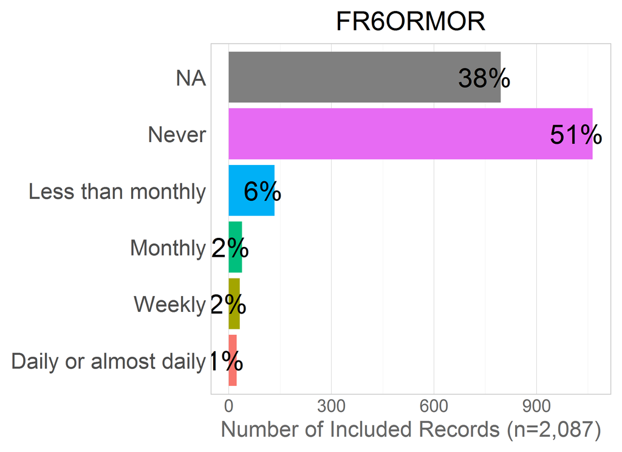

```r
dto[["unitData"]][["alsa"]]%>% histogram_discrete("FR6ORMOR")
```

```r
dto[["unitData"]][["alsa"]]%>% dplyr::group_by_("FR6ORMOR") %>% dplyr::summarize(n=n())
```

```
Source: local data frame [6 x 2]

               FR6ORMOR     n
                 (fctr) (int)
1                 Never  1064
2     Less than monthly   134
3               Monthly    39
4                Weekly    32
5 Daily or almost daily    23
6                    NA   795
```

## FREQALCH

```r
dto[["metaData"]] %>% dplyr::filter(study_name=="alsa", name=="FREQALCH") %>% dplyr::select(name,label)
```

```
      name             label
1 FREQALCH Frequency alcohol
```

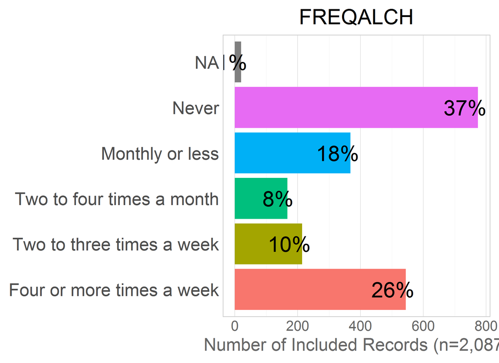

```r
dto[["unitData"]][["alsa"]]%>% histogram_discrete("FREQALCH")
```

```r
dto[["unitData"]][["alsa"]]%>% dplyr::group_by_("FREQALCH") %>% dplyr::summarize(n=n())
```

```
Source: local data frame [6 x 2]

                   FREQALCH     n
                     (fctr) (int)
1                     Never   774
2           Monthly or less   368
3 Two to four times a month   167
4 Two to three times a week   214
5 Four or more times a week   544
6                        NA    20
```

## NOSTDRNK

```r
dto[["metaData"]] %>% dplyr::filter(study_name=="alsa", name=="NOSTDRNK") %>% dplyr::select(name,label)
```

```
      name                     label
1 NOSTDRNK Number of standard drinks
```

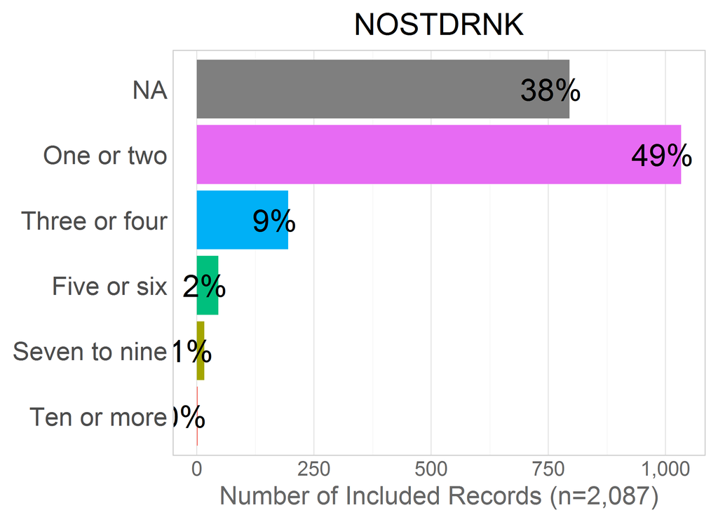

```r
dto[["unitData"]][["alsa"]]%>% histogram_discrete("NOSTDRNK")
```

```r
dto[["unitData"]][["alsa"]]%>% dplyr::group_by_("NOSTDRNK") %>% dplyr::summarize(n=n())
```

```
Source: local data frame [6 x 2]

       NOSTDRNK     n
         (fctr) (int)
1    One or two  1033
2 Three or four   195
3   Five or six    46
4 Seven to nine    16
5   Ten or more     2
6            NA   795
```

# LBSL

## ALCOHOL

```r
dto[["metaData"]] %>% dplyr::filter(study_name=="lbsl", name=="ALCOHOL") %>% dplyr::select(name,label)
```

```
     name       label
1 ALCOHOL Alcohol use
```

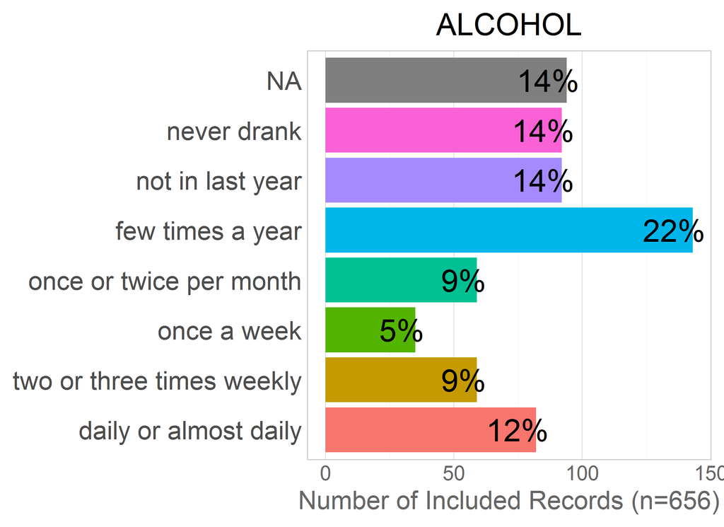

```r
dto[["unitData"]][["lbsl"]]%>% histogram_discrete("ALCOHOL")
```

```r
dto[["unitData"]][["lbsl"]]%>% dplyr::group_by_("ALCOHOL") %>% dplyr::summarize(n=n())
```

```
Source: local data frame [8 x 2]

                    ALCOHOL     n
                     (fctr) (int)
1               never drank    92
2          not in last year    92
3          few times a year   143
4   once or twice per month    59
5               once a week    35
6 two or three times weekly    59
7     daily or almost daily    82
8                        NA    94
```

## BEER

```r
# requires categorization
dto[["metaData"]] %>% dplyr::filter(study_name=="lbsl", name=="BEER") %>% dplyr::select(name,label)
```

```
  name                                    label
1 BEER Number of cans/bottles of beer last week
```

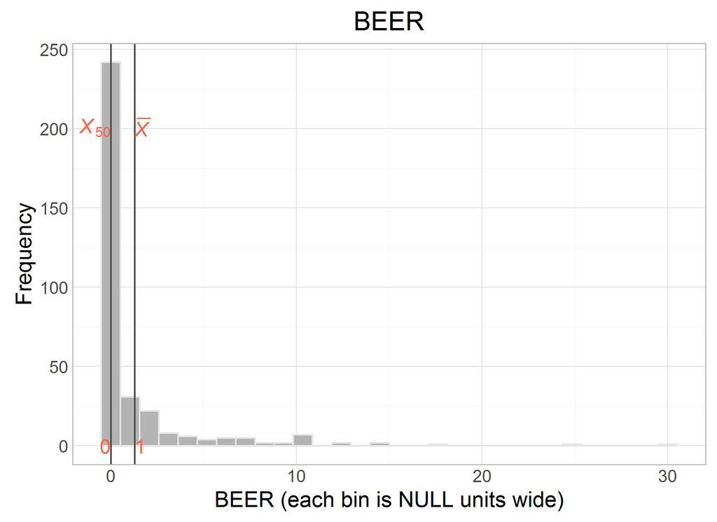

```r
dto[["unitData"]][["lbsl"]]%>% histogram_continuous("BEER")
```

```r
dto[["unitData"]][["lbsl"]]%>% dplyr::group_by_("BEER") %>% dplyr::summarize(n=n())
```

```
Source: local data frame [18 x 2]

    BEER     n
   (int) (int)
1      0   242
2      1    31
3      2    22
4      3     8
5      4     6
6      5     4
7      6     5
8      7     5
9      8     2
10     9     2
11    10     7
12    12     2
13    14     1
14    15     1
15    18     1
16    25     1
17    30     1
18    NA   315
```

## HARDLIQ

```r
# requires categorization
dto[["metaData"]] %>% dplyr::filter(study_name=="lbsl", name=="HARDLIQ") %>% dplyr::select(name,label)
```

```
     name                                             label
1 HARDLIQ Number of drinks containing hard liquor last week
```

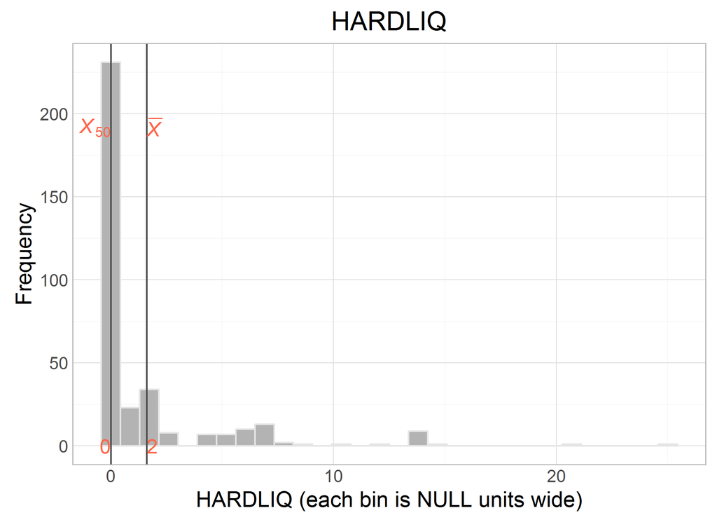

```r
dto[["unitData"]][["lbsl"]]%>% histogram_continuous("HARDLIQ")
```

```r
dto[["unitData"]][["lbsl"]]%>% dplyr::group_by_("HARDLIQ") %>% dplyr::summarize(n=n())
```

```
Source: local data frame [17 x 2]

   HARDLIQ     n
     (int) (int)
1        0   231
2        1    23
3        2    34
4        3     8
5        4     7
6        5     7
7        6    10
8        7    13
9        8     2
10       9     1
11      10     1
12      12     1
13      14     9
14      15     1
15      21     1
16      25     1
17      NA   306
```

## WINE

```r
# requires categorization
dto[["metaData"]] %>% dplyr::filter(study_name=="lbsl", name=="WINE") %>% dplyr::select(name,label)
```

```
  name                               label
1 WINE Number of glasses of wine last week
```

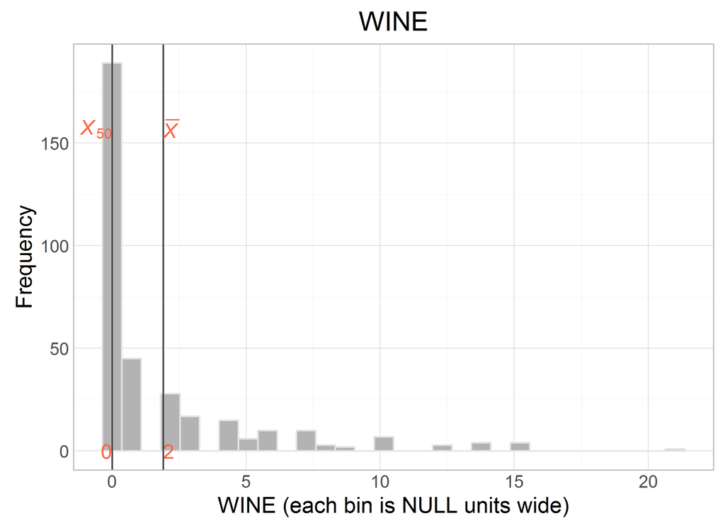

```r
dto[["unitData"]][["lbsl"]]%>% histogram_continuous("WINE")
```

```r
dto[["unitData"]][["lbsl"]]%>% dplyr::group_by_("WINE") %>% dplyr::summarize(n=n())
```

```
Source: local data frame [16 x 2]

    WINE     n
   (int) (int)
1      0   189
2      1    45
3      2    28
4      3    17
5      4    15
6      5     6
7      6    10
8      7    10
9      8     3
10     9     2
11    10     7
12    12     3
13    14     4
14    15     4
15    21     1
16    NA   312
```

# SATSA

## GALCOHOL

```r
dto[["metaData"]] %>% dplyr::filter(study_name=="satsa", name=="GALCOHOL") %>% dplyr::select(name,label)
```

```
      name                                  label
1 GALCOHOL Do you ever drink alcoholic beverages?
```

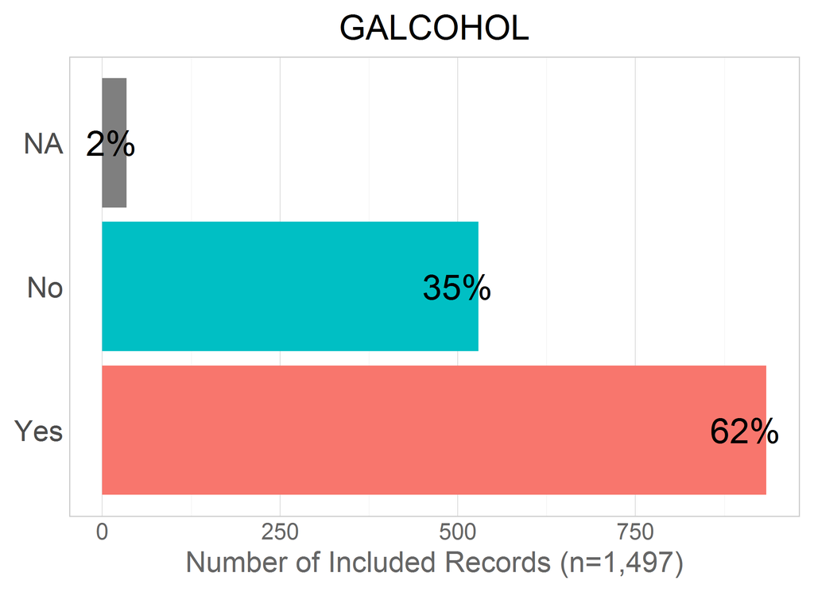

```r
dto[["unitData"]][["satsa"]]%>% histogram_discrete("GALCOHOL")
```

```r
dto[["unitData"]][["satsa"]]%>% dplyr::group_by_("GALCOHOL") %>% dplyr::summarize(n=n())
```

```
Source: local data frame [3 x 2]

  GALCOHOL     n
    (fctr) (int)
1       No   529
2      Yes   934
3       NA    34
```

## GBEERX

```r
dto[["metaData"]] %>% dplyr::filter(study_name=="satsa", name=="GBEERX") %>% dplyr::select(name,label)
```

```
    name                                         label
1 GBEERX How much beer do you usually drink at a time?
```

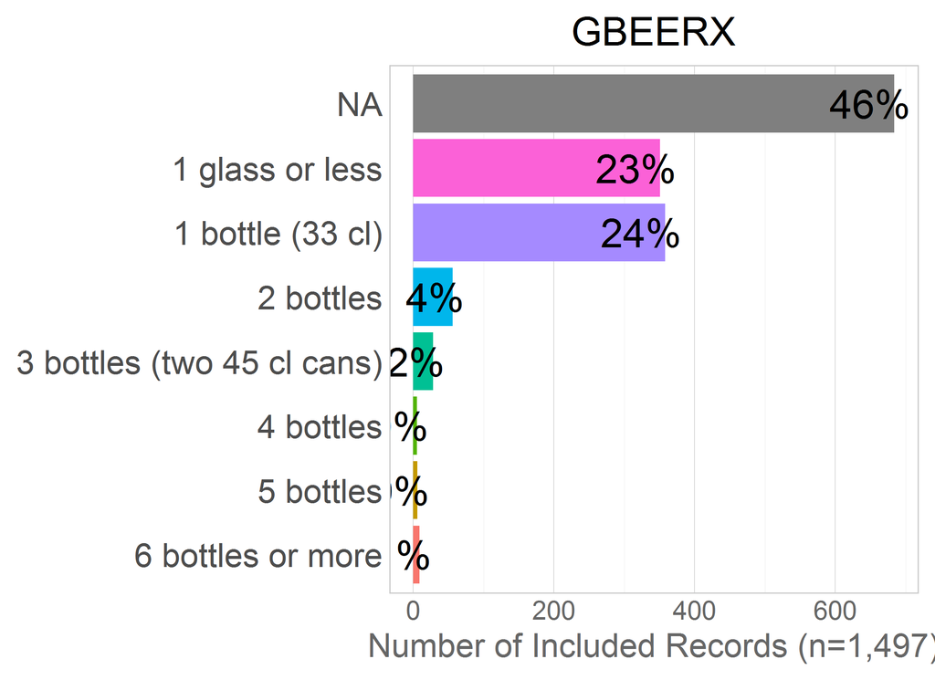

```r
dto[["unitData"]][["satsa"]]%>% histogram_discrete("GBEERX")
```

```r
dto[["unitData"]][["satsa"]]%>% dplyr::group_by_("GBEERX") %>% dplyr::summarize(n=n())
```

```
Source: local data frame [8 x 2]

                      GBEERX     n
                      (fctr) (int)
1            1 glass or less   351
2           1 bottle (33 cl)   358
3                  2 bottles    56
4 3 bottles (two 45 cl cans)    28
5                  4 bottles     5
6                  5 bottles     6
7          6 bottles or more     9
8                         NA   684
```

## GBOTVIN

```r
dto[["metaData"]] %>% dplyr::filter(study_name=="satsa", name=="GBOTVIN") %>% dplyr::select(name,label)
```

```
     name                                                                    label
1 GBOTVIN ..more than 1 bottle, i.e.____bottles (state number of bottles): GBOTVIN
```

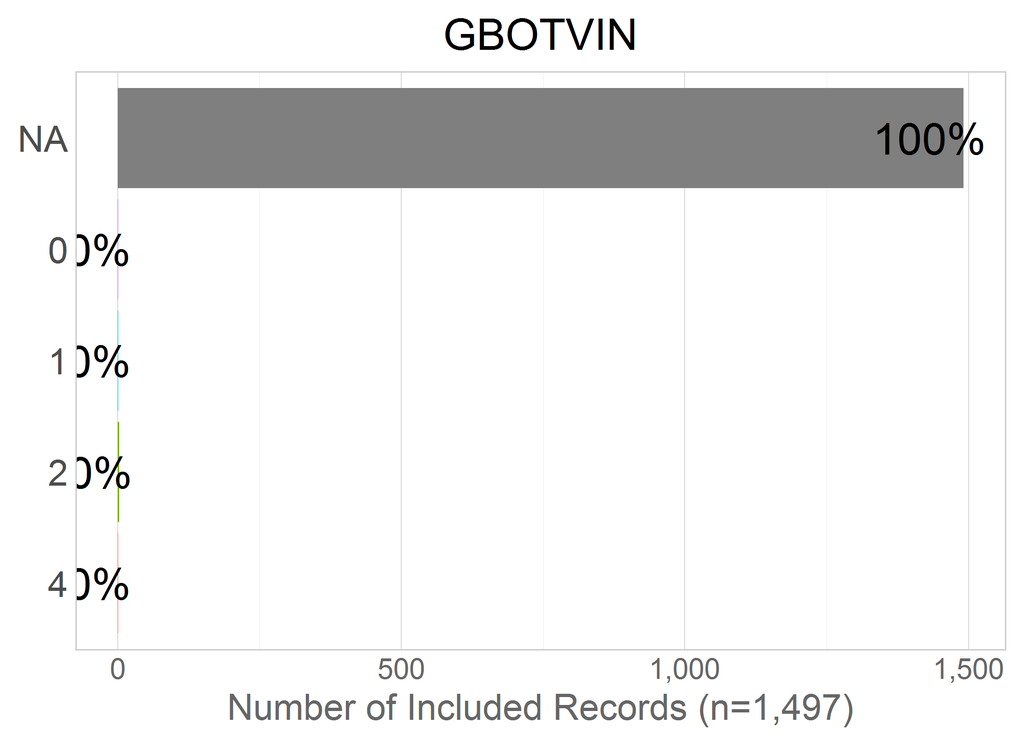

```r
dto[["unitData"]][["satsa"]]%>% histogram_discrete("GBOTVIN")
```

```r
dto[["unitData"]][["satsa"]]%>% dplyr::group_by_("GBOTVIN") %>% dplyr::summarize(n=n())
```

```
Source: local data frame [5 x 2]

  GBOTVIN     n
    (int) (int)
1       0     1
2       1     1
3       2     3
4       4     1
5      NA  1491
```

## GDRLOTS

```r
dto[["metaData"]] %>% dplyr::filter(study_name=="satsa", name=="GDRLOTS") %>% dplyr::select(name,label)
```

```
     name
1 GDRLOTS
                                                                                                                                    label
1 How often do you consume more than five bottles of beer or more than one bottle of wine or more than 1/2 bottle liquot at one occasion?
```

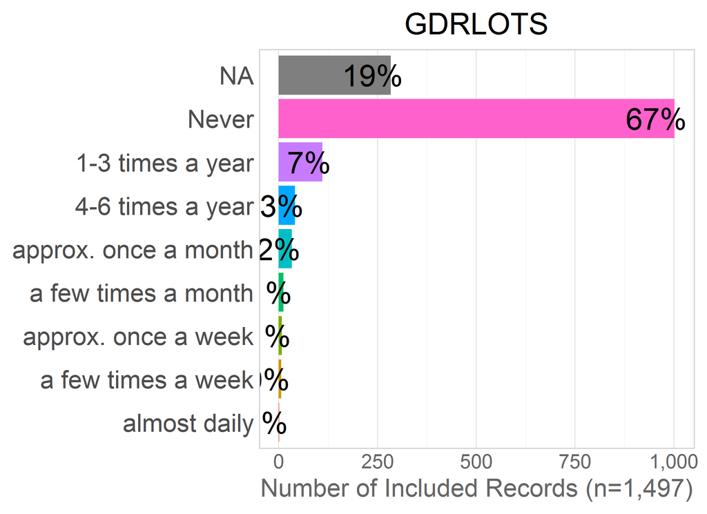

```r
dto[["unitData"]][["satsa"]]%>% histogram_discrete("GDRLOTS")
```

```r
dto[["unitData"]][["satsa"]]%>% dplyr::group_by_("GDRLOTS") %>% dplyr::summarize(n=n())
```

```
Source: local data frame [9 x 2]

               GDRLOTS     n
                (fctr) (int)
1                Never  1002
2     1-3 times a year   110
3     4-6 times a year    41
4 approx. once a month    33
5  a few times a month    12
6  approx. once a week     8
7   a few times a week     6
8         almost daily     1
9                   NA   284
```

## GEVRALK

```r
dto[["metaData"]] %>% dplyr::filter(study_name=="satsa", name=="GEVRALK") %>% dplyr::select(name,label)
```

```
     name                                     label
1 GEVRALK Do you ever drink alcoholic drinks? - Yes
```

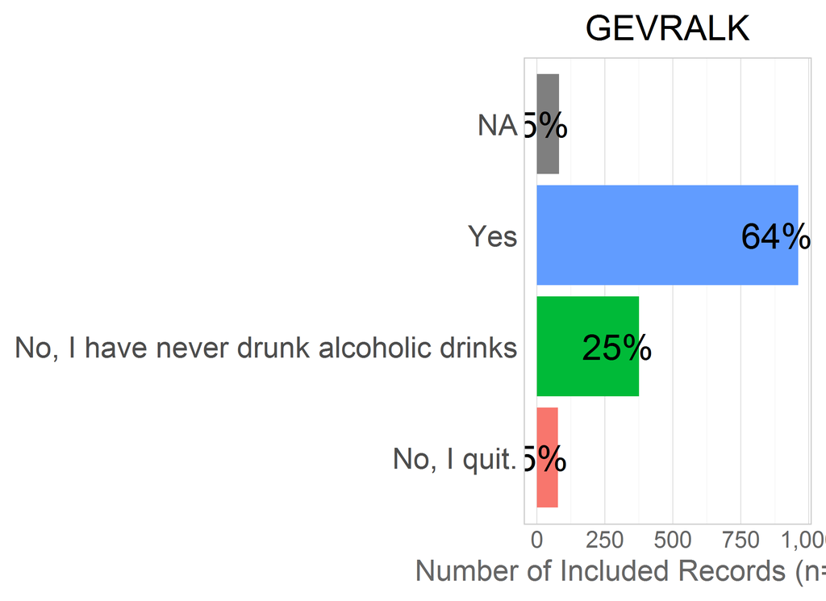

```r
dto[["unitData"]][["satsa"]]%>% histogram_discrete("GEVRALK")
```

```r
dto[["unitData"]][["satsa"]]%>% dplyr::group_by_("GEVRALK") %>% dplyr::summarize(n=n())
```

```
Source: local data frame [4 x 2]

                                  GEVRALK     n
                                   (fctr) (int)
1                                     Yes   961
2 No, I have never drunk alcoholic drinks   376
3                             No, I quit.    78
4                                      NA    82
```

## GFREQBER

```r
dto[["metaData"]] %>% dplyr::filter(study_name=="satsa", name=="GFREQBER") %>% dplyr::select(name,label)
```

```
      name                                         label
1 GFREQBER How often do you drink beer (not light beer)?
```

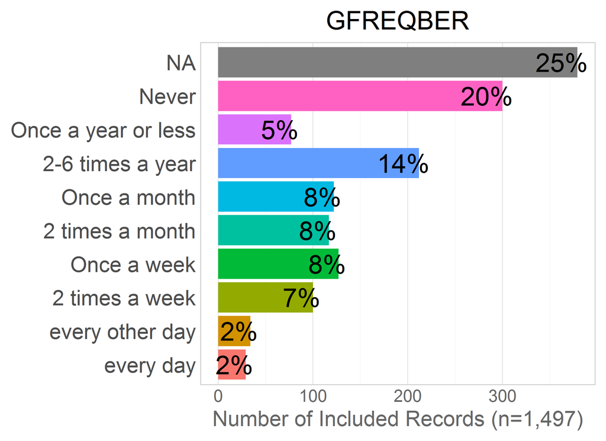

```r
dto[["unitData"]][["satsa"]]%>% histogram_discrete("GFREQBER")
```

```r
dto[["unitData"]][["satsa"]]%>% dplyr::group_by_("GFREQBER") %>% dplyr::summarize(n=n())
```

```
Source: local data frame [10 x 2]

              GFREQBER     n
                (fctr) (int)
1                Never   300
2  Once a year or less    77
3     2-6 times a year   212
4         Once a month   122
5      2 times a month   117
6          Once a week   127
7       2 times a week   100
8      every other day    34
9            every day    29
10                  NA   379
```

## GFREQLIQ

```r
dto[["metaData"]] %>% dplyr::filter(study_name=="satsa", name=="GFREQLIQ") %>% dplyr::select(name,label)
```

```
      name
1 GFREQLIQ
                                                                                                                               label
1 How often do you usually drink hard liquor? (e.g. aquavit, whiskey, gin, brandy, punsch. Also liquot in cocktails and long drinks)
```

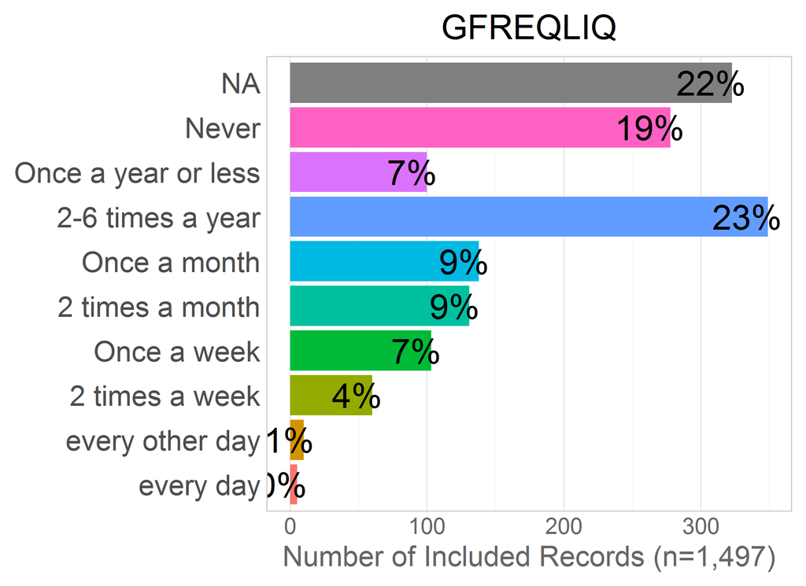

```r
dto[["unitData"]][["satsa"]]%>% histogram_discrete("GFREQLIQ")
```

```r
dto[["unitData"]][["satsa"]]%>% dplyr::group_by_("GFREQLIQ") %>% dplyr::summarize(n=n())
```

```
Source: local data frame [10 x 2]

              GFREQLIQ     n
                (fctr) (int)
1                Never   278
2  Once a year or less   100
3     2-6 times a year   349
4         Once a month   138
5      2 times a month   131
6          Once a week   103
7       2 times a week    60
8      every other day    10
9            every day     5
10                  NA   323
```

## GFREQVIN

```r
dto[["metaData"]] %>% dplyr::filter(study_name=="satsa", name=="GFREQVIN") %>% dplyr::select(name,label)
```

```
      name                                               label
1 GFREQVIN How often do you usually drink wine (red or white)?
```

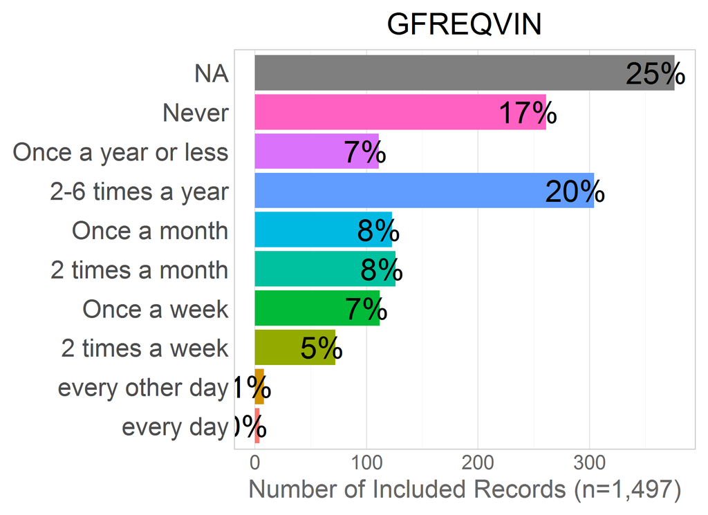

```r
dto[["unitData"]][["satsa"]]%>% histogram_discrete("GFREQVIN")
```

```r
dto[["unitData"]][["satsa"]]%>% dplyr::group_by_("GFREQVIN") %>% dplyr::summarize(n=n())
```

```
Source: local data frame [10 x 2]

              GFREQVIN     n
                (fctr) (int)
1                Never   261
2  Once a year or less   111
3     2-6 times a year   304
4         Once a month   123
5      2 times a month   126
6          Once a week   112
7       2 times a week    72
8      every other day     8
9            every day     4
10                  NA   376
```

## GLIQX

```r
dto[["metaData"]] %>% dplyr::filter(study_name=="satsa", name=="GLIQX") %>% dplyr::select(name,label)
```

```
   name                                              label
1 GLIQX How much hard liquot do you usually drink at time?
```

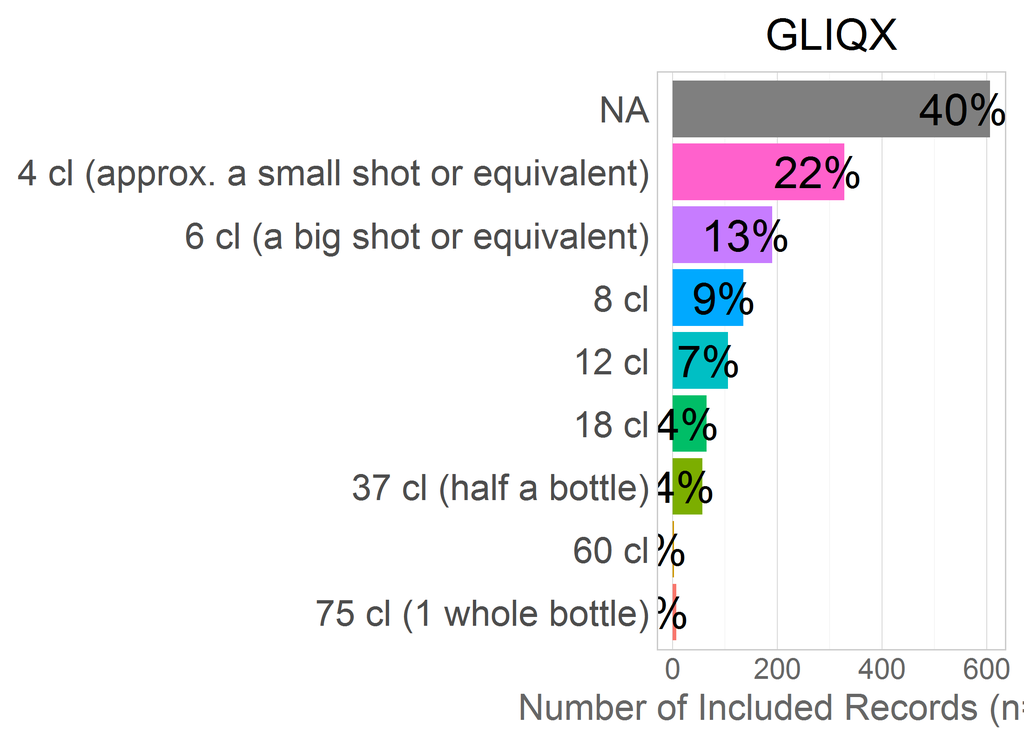

```r
dto[["unitData"]][["satsa"]]%>% histogram_discrete("GLIQX")
```

```r
dto[["unitData"]][["satsa"]]%>% dplyr::group_by_("GLIQX") %>% dplyr::summarize(n=n())
```

```
Source: local data frame [9 x 2]

                                      GLIQX     n
                                     (fctr) (int)
1 4 cl (approx. a small shot or equivalent)   328
2           6 cl (a big shot or equivalent)   190
3                                      8 cl   135
4                                     12 cl   106
5                                     18 cl    65
6                     37 cl (half a bottle)    57
7                                     60 cl     3
8                    75 cl (1 whole bottle)     7
9                                        NA   606
```

## GSTOPALK

```r
# requires categorization? maybe, maybe not
dto[["metaData"]] %>% dplyr::filter(study_name=="satsa", name=="GSTOPALK") %>% dplyr::select(name,label)
```

```
      name                                                      label
1 GSTOPALK Do you ever drink alcoholic drinks? -No I quit. When? 19__
```

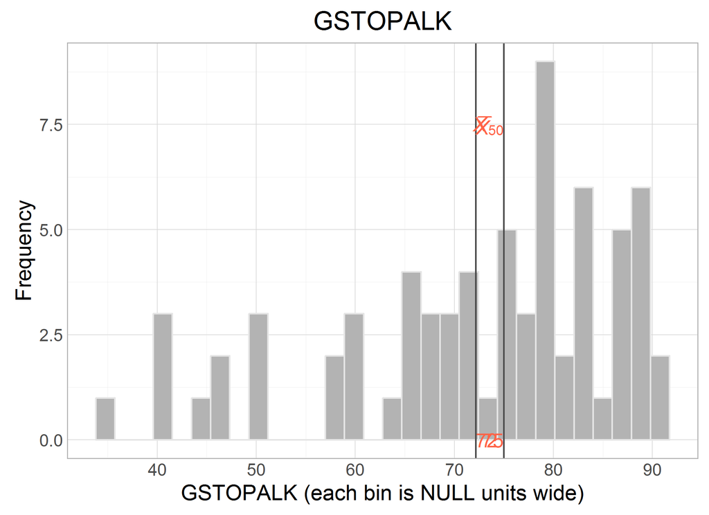

```r
dto[["unitData"]][["satsa"]]%>% histogram_continuous("GSTOPALK")
```

```r
dto[["unitData"]][["satsa"]]%>% dplyr::group_by_("GSTOPALK") %>% dplyr::summarize(n=n())
```

```
Source: local data frame [33 x 2]

   GSTOPALK     n
      (int) (int)
1        34     1
2        40     2
3        41     1
4        44     1
5        46     1
6        47     1
7        50     3
8        58     2
9        59     1
10       60     2
..      ...   ...
```

## GVINX

```r
dto[["metaData"]] %>% dplyr::filter(study_name=="satsa", name=="GVINX") %>% dplyr::select(name,label)
```

```
   name                                         label
1 GVINX How much wine do you usually drink at a time?
```

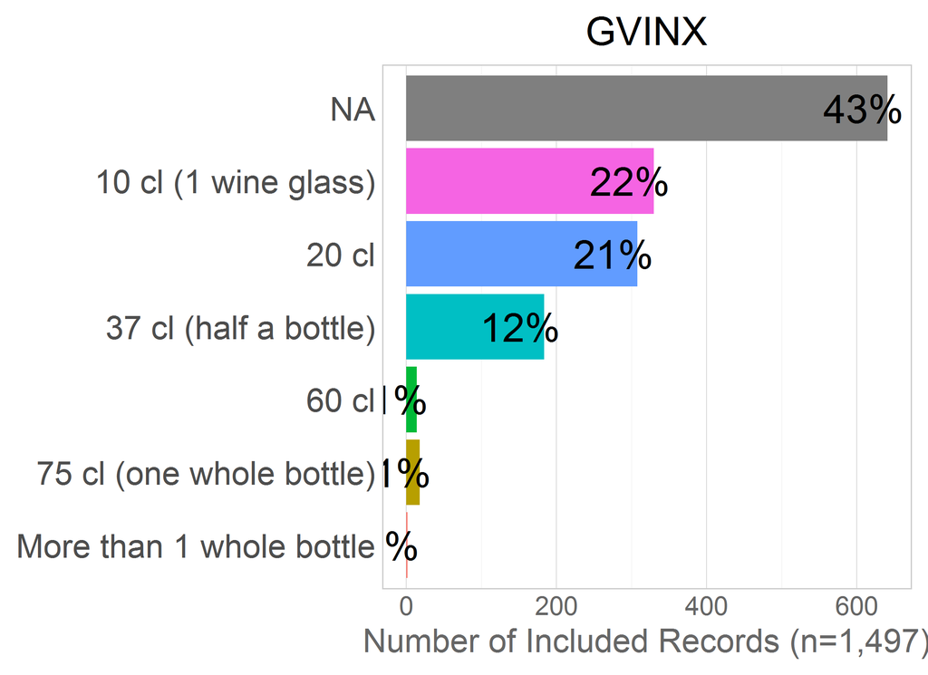

```r
dto[["unitData"]][["satsa"]]%>% histogram_discrete("GVINX")
```

```r
dto[["unitData"]][["satsa"]]%>% dplyr::group_by_("GVINX") %>% dplyr::summarize(n=n())
```

```
Source: local data frame [7 x 2]

                     GVINX     n
                    (fctr) (int)
1     10 cl (1 wine glass)   330
2                    20 cl   308
3    37 cl (half a bottle)   184
4                    60 cl    14
5 75 cl (one whole bottle)    18
6 More than 1 whole bottle     2
7                       NA   641
```

# SHARE

## BR0100

```r
dto[["metaData"]] %>% dplyr::filter(study_name=="share", name=="BR0100") %>% dplyr::select(name,label)
```

```
    name                            label
1 BR0100 beverages consumed last 6 months
```

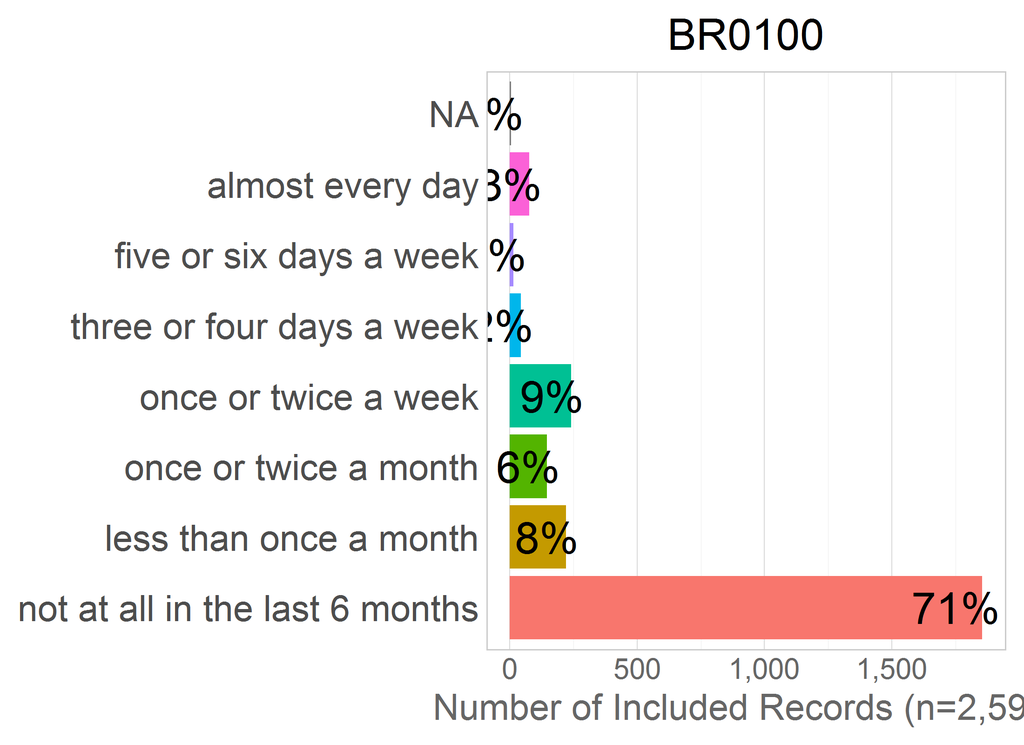

```r
dto[["unitData"]][["share"]]%>% histogram_discrete("BR0100")
```

```r
dto[["unitData"]][["share"]]%>% dplyr::group_by_("BR0100") %>% dplyr::summarize(n=n())
```

```
Source: local data frame [8 x 2]

                           BR0100     n
                           (fctr) (int)
1                almost every day    76
2         five or six days a week    14
3       three or four days a week    43
4            once or twice a week   240
5           once or twice a month   146
6          less than once a month   220
7 not at all in the last 6 months  1855
8                              NA     4
```

## BR0110

```r
dto[["metaData"]] %>% dplyr::filter(study_name=="share", name=="BR0110") %>% dplyr::select(name,label)
```

```
    name                                  label
1 BR0110 freq more than 2 glasses beer in a day
```

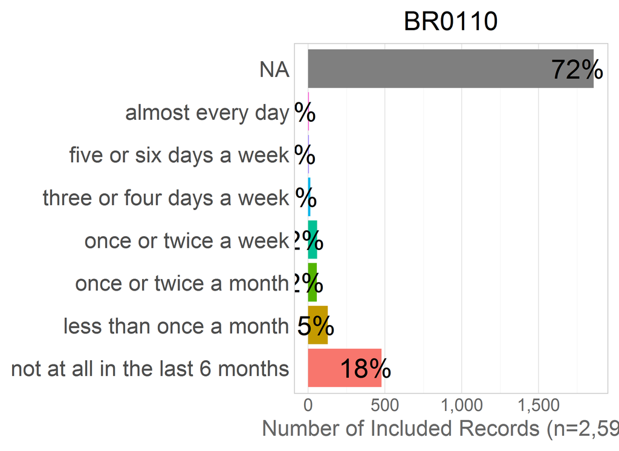

```r
dto[["unitData"]][["share"]]%>% histogram_discrete("BR0110")
```

```r
dto[["unitData"]][["share"]]%>% dplyr::group_by_("BR0110") %>% dplyr::summarize(n=n())
```

```
Source: local data frame [8 x 2]

                           BR0110     n
                           (fctr) (int)
1                almost every day     5
2         five or six days a week     4
3       three or four days a week    13
4            once or twice a week    57
5           once or twice a month    56
6          less than once a month   127
7 not at all in the last 6 months   477
8                              NA  1859
```

## BR0120

```r
dto[["metaData"]] %>% dplyr::filter(study_name=="share", name=="BR0120") %>% dplyr::select(name,label)
```

```
    name                                  label
1 BR0120 freq more than 2 glasses wine in a day
```

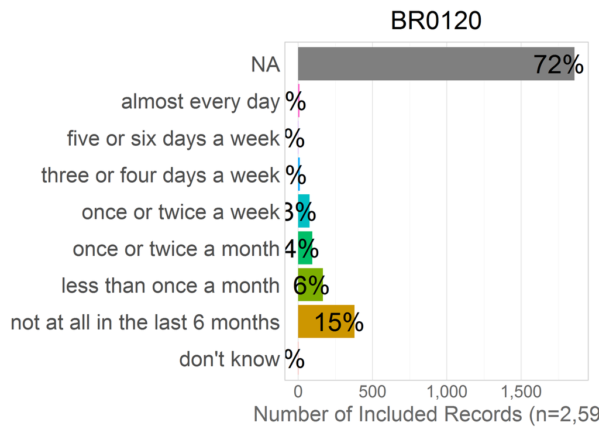

```r
dto[["unitData"]][["share"]]%>% histogram_discrete("BR0120")
```

```r
dto[["unitData"]][["share"]]%>% dplyr::group_by_("BR0120") %>% dplyr::summarize(n=n())
```

```
Source: local data frame [9 x 2]

                           BR0120     n
                           (fctr) (int)
1                almost every day     9
2         five or six days a week     1
3       three or four days a week    11
4            once or twice a week    77
5           once or twice a month    95
6          less than once a month   166
7 not at all in the last 6 months   379
8                      don't know     1
9                              NA  1859
```

## BR0130

```r
dto[["metaData"]] %>% dplyr::filter(study_name=="share", name=="BR0130") %>% dplyr::select(name,label)
```

```
    name                                 label
1 BR0130 freq more than 2 hard liquor in a day
```

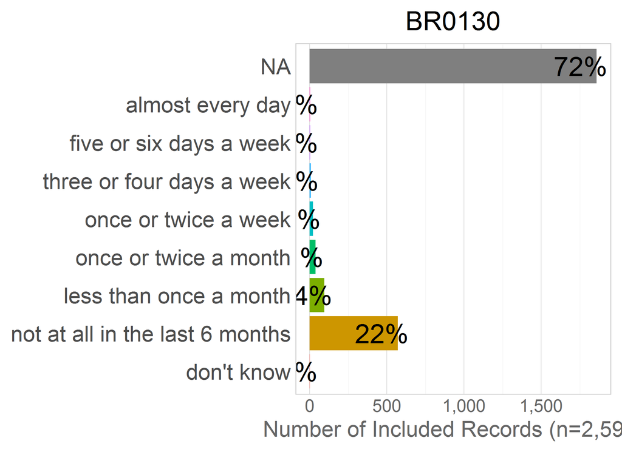

```r
dto[["unitData"]][["share"]]%>% histogram_discrete("BR0130")
```

```r
dto[["unitData"]][["share"]]%>% dplyr::group_by_("BR0130") %>% dplyr::summarize(n=n())
```

```
Source: local data frame [9 x 2]

                           BR0130     n
                           (fctr) (int)
1                almost every day     3
2         five or six days a week     3
3       three or four days a week     7
4            once or twice a week    21
5           once or twice a month    38
6          less than once a month    95
7 not at all in the last 6 months   571
8                      don't know     1
9                              NA  1859
```

# TILDA

## DRINKSPERDAY

```r
# requires categorization
dto[["metaData"]] %>% dplyr::filter(study_name=="tilda", name=="BEHALC.DRINKSPERDAY") %>% dplyr::select(name,label)
```

```
                 name                                        label
1 BEHALC.DRINKSPERDAY BEHalc_drinksperday  Standard drinks per day
```

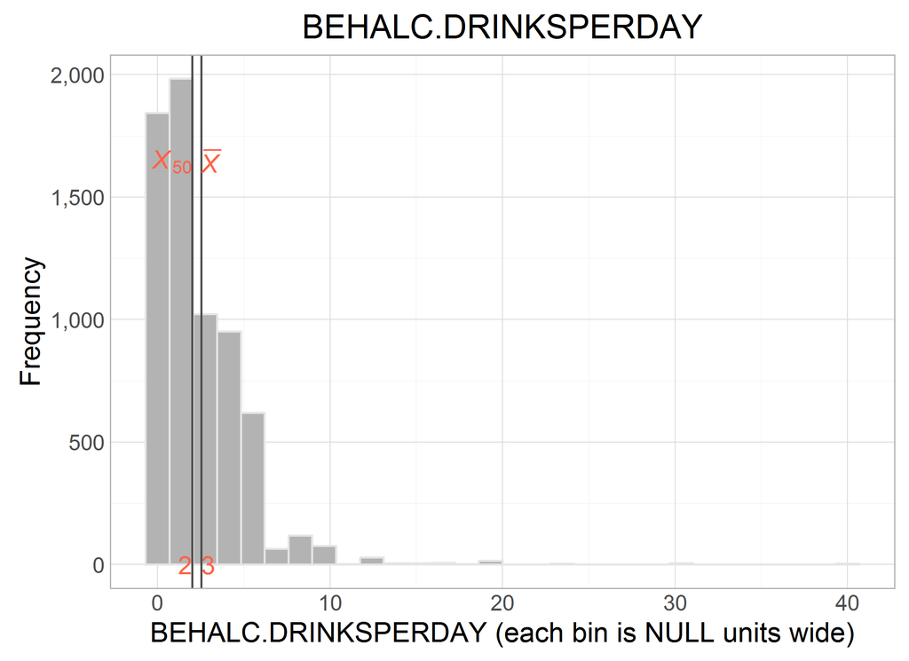

```r
dto[["unitData"]][["tilda"]]%>% histogram_continuous("BEHALC.DRINKSPERDAY")
```

```r
dto[["unitData"]][["tilda"]]%>% dplyr::group_by_("BEHALC.DRINKSPERDAY") %>% dplyr::summarize(n=n())
```

```
Source: local data frame [36 x 2]

   BEHALC.DRINKSPERDAY     n
                 (dbl) (int)
1                  0.0  1835
2                  0.5     8
3                  0.7     1
4                  1.0   631
5                  1.5   139
6                  2.0  1212
7                  2.5   199
8                  3.0   823
9                  3.5   152
10                 4.0   731
..                 ...   ...
```

## DRINKSPERWEEK

```r
# requires categorization
dto[["metaData"]] %>% dplyr::filter(study_name=="tilda", name=="BEHALC.DRINKSPERWEEK") %>% dplyr::select(name,label)
```

```
                  name                                        label
1 BEHALC.DRINKSPERWEEK BEHalc_drinksperweek  Standard drinks a week
```

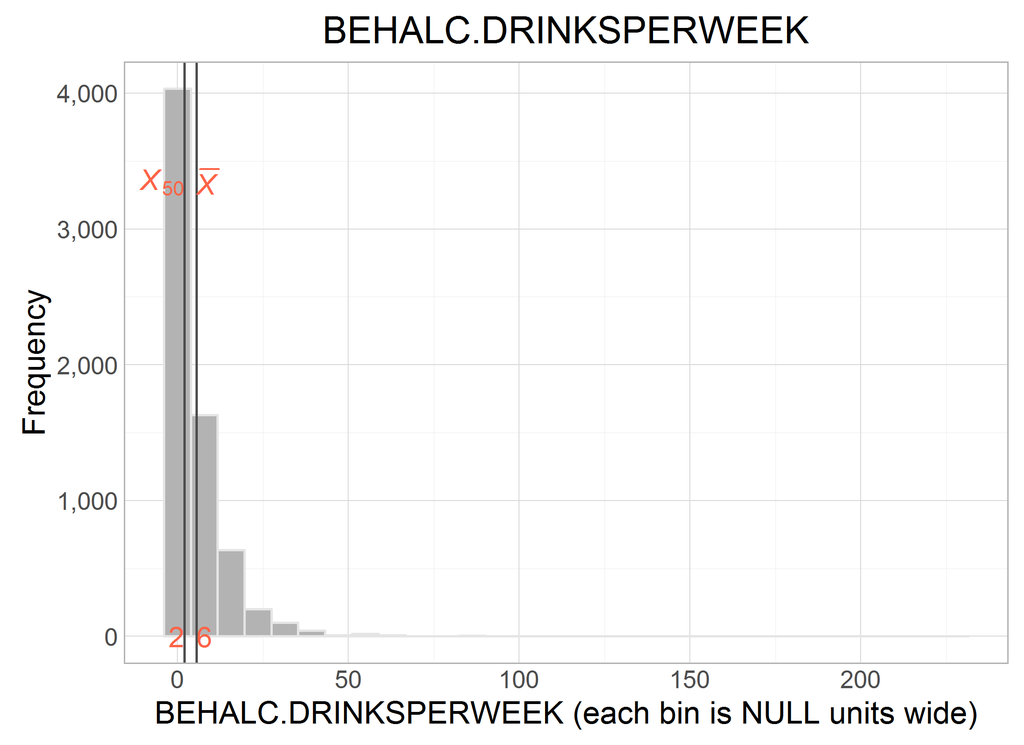

```r
dto[["unitData"]][["tilda"]]%>% histogram_continuous("BEHALC.DRINKSPERWEEK")
```

```r
dto[["unitData"]][["tilda"]]%>% dplyr::group_by_("BEHALC.DRINKSPERWEEK") %>% dplyr::summarize(n=n())
```

```
Source: local data frame [121 x 2]

   BEHALC.DRINKSPERWEEK     n
                  (dbl) (int)
1                 0.000  1893
2                 0.060     3
3                 0.084     1
4                 0.120   181
5                 0.180    19
6                 0.240   171
7                 0.300    11
8                 0.350   152
9                 0.360    76
10                0.420     6
..                  ...   ...
```

## BEHALC.FREQ.WEEK

```r
dto[["metaData"]] %>% dplyr::filter(study_name=="tilda", name=="BEHALC.FREQ.WEEK") %>% dplyr::select(name,label)
```

```
              name                                             label
1 BEHALC.FREQ.WEEK BEHalc_freq_week  Average times drinking per week
```

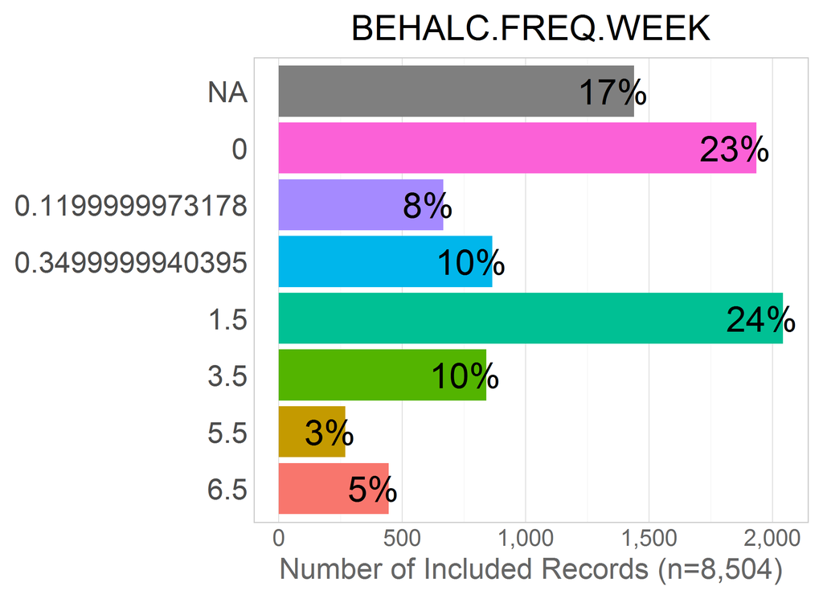

```r
dto[["unitData"]][["tilda"]]%>% histogram_discrete("BEHALC.FREQ.WEEK")
```

```r
dto[["unitData"]][["tilda"]]%>% dplyr::group_by_("BEHALC.FREQ.WEEK") %>% dplyr::summarize(n=n())
```

```
Source: local data frame [8 x 2]

  BEHALC.FREQ.WEEK     n
             (dbl) (int)
1             0.00  1935
2             0.12   667
3             0.35   865
4             1.50  2043
5             3.50   841
6             5.50   269
7             6.50   445
8               NA  1439
```

## SCQALCOFREQ

```r
# requires labelling factor levels
dto[["metaData"]] %>% dplyr::filter(study_name=="tilda", name=="SCQALCOFREQ") %>% dplyr::select(name,label)
```

```
         name                                      label
1 SCQALCOFREQ SCQalcofreq  frequency of drinking alcohol
```

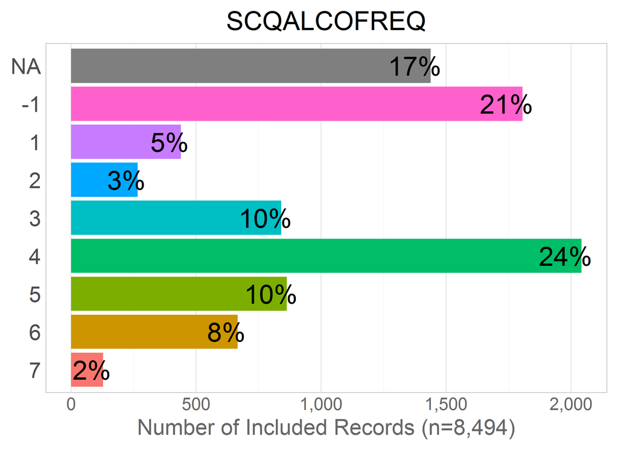

```r
dto[["unitData"]][["tilda"]]%>%
  dplyr::filter(!SCQALCOFREQ %in% c(-867,-856,-845,-823,-812)) %>% histogram_discrete("SCQALCOFREQ")
```

```r
dto[["unitData"]][["tilda"]]%>% dplyr::group_by_("SCQALCOFREQ") %>% dplyr::summarize(n=n())
```

```
Source: local data frame [13 x 2]

   SCQALCOFREQ     n
         (int) (int)
1         -856     2
2         -845     1
3         -823     2
4         -812     5
5           -1  1806
6            1   440
7            2   267
8            3   841
9            4  2042
10           5   863
11           6   667
12           7   129
13          NA  1439
```

## SCQALCOHOL

```r
dto[["metaData"]] %>% dplyr::filter(study_name=="tilda", name=="SCQALCOHOL") %>% dplyr::select(name,label)
```

```
        name                     label
1 SCQALCOHOL SCQalcohol  drink alcohol
```

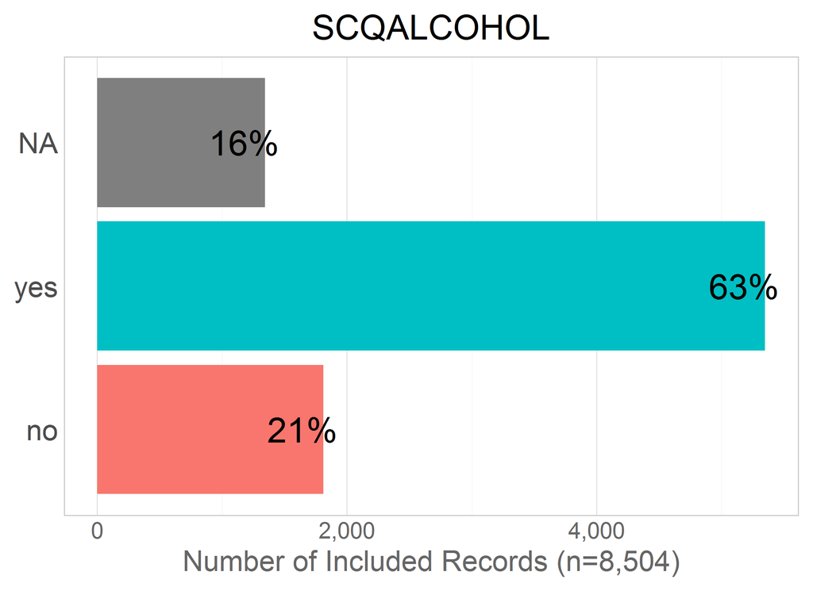

```r
dto[["unitData"]][["tilda"]]%>% histogram_discrete("SCQALCOHOL")
```

```r
dto[["unitData"]][["tilda"]]%>% dplyr::group_by_("SCQALCOHOL") %>% dplyr::summarize(n=n())
```

```
Source: local data frame [3 x 2]

  SCQALCOHOL     n
      (fctr) (int)
1        yes  5349
2         no  1812
3         NA  1343
```

## SCQALCONO1

```r
dto[["metaData"]] %>% dplyr::filter(study_name=="tilda", name=="SCQALCONO1") %>% dplyr::select(name,label)
```

```
        name                                            label
1 SCQALCONO1 SCQalcono1  more than two drinks in a single day
```

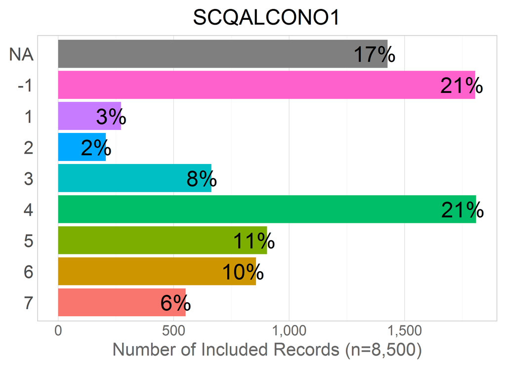

```r
dto[["unitData"]][["tilda"]]%>%
  dplyr::filter(!SCQALCONO1 %in% c(-867,-856,-845,-823,-812)) %>% histogram_discrete("SCQALCONO1")
```

```r
dto[["unitData"]][["tilda"]]%>% dplyr::group_by_("SCQALCONO1") %>% dplyr::summarize(n=n())
```

```
Source: local data frame [12 x 2]

   SCQALCONO1     n
        (int) (int)
1        -867     1
2        -856     2
3        -812     1
4          -1  1806
5           1   272
6           2   207
7           3   664
8           4  1810
9           5   905
10          6   857
11          7   552
12         NA  1427
```

## SCQALCONO2

```r
dto[["metaData"]] %>% dplyr::filter(study_name=="tilda", name=="SCQALCONO2") %>% dplyr::select(name,label)
```

```
        name                                                    label
1 SCQALCONO2 SCQalcono2  How many drinks consumed on days drink taken
```

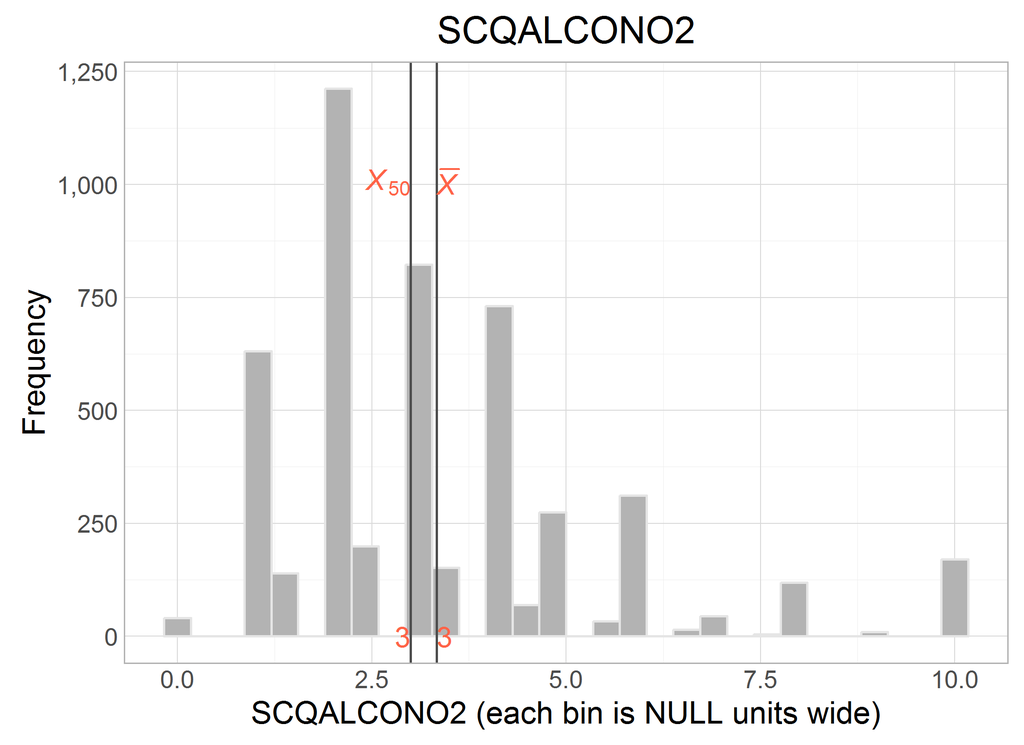

```r
dto[["unitData"]][["tilda"]]%>%
  dplyr::filter(!SCQALCONO2 %in% c(-99, -1 )) %>%  histogram_continuous("SCQALCONO2")
```

```r
dto[["unitData"]][["tilda"]]%>% dplyr::group_by_("SCQALCONO2") %>% dplyr::summarize(n=n())
```

```
Source: local data frame [21 x 2]

   SCQALCONO2     n
        (dbl) (int)
1       -99.0   405
2        -1.0  1803
3         0.0    41
4         1.0   631
5         1.5   139
6         2.0  1212
7         2.5   199
8         3.0   823
9         3.5   152
10        4.0   731
..        ...   ...
```